# The PAS Premium

author: Jeremy Leipzig date: 6/1/16 autosize: false width: 1920 height: 1080

# Background & Timeline

- Sadie Tanner Mossell Alexander - envisanged in 1998, completed in 2001
- 500 students
- $1330 per student from UPenn
- At capacity by 2011, 2013 winter debacle, lotteries conducted but no denials in 2014, 2015, 2016

# PAS Premium Heuristics and Previous Studies

- A “$100k premium”
- “In fact, prices of homes can jump $50,000 or even $100,000 if they’re in the Penn Alexander catchment—even if they’re exactly the same kind of homes as the non-catchment homes across the street.” [Curbed](http://philly.curbed.com/2013/1/16/10284824/penn-alexander-catchment-problem-has-obvious-solution) 1/16/13
- [Penn Urban Research](http://www.slideshare.net/PennUrbanResearch/neighborhood-value-updated-west-philadelphia-price-indexes)
- No pricing models I could find

# Questions

- Is there really a catchment premium?
- Did it exist before the school was built?
- Does it affect rentals?

# Analysis strategy

- Focus on border properties
- Linear regression & conditional logistic regression modeling
- Use Philadelphia Office of Property Assessment API and Casey Thomas’ PHL-opa wrapper
- Statistics and visualization in R with Leaflet for mapping

# Property Data JSON

class: small-code

[output not shown]

# Choosing properties

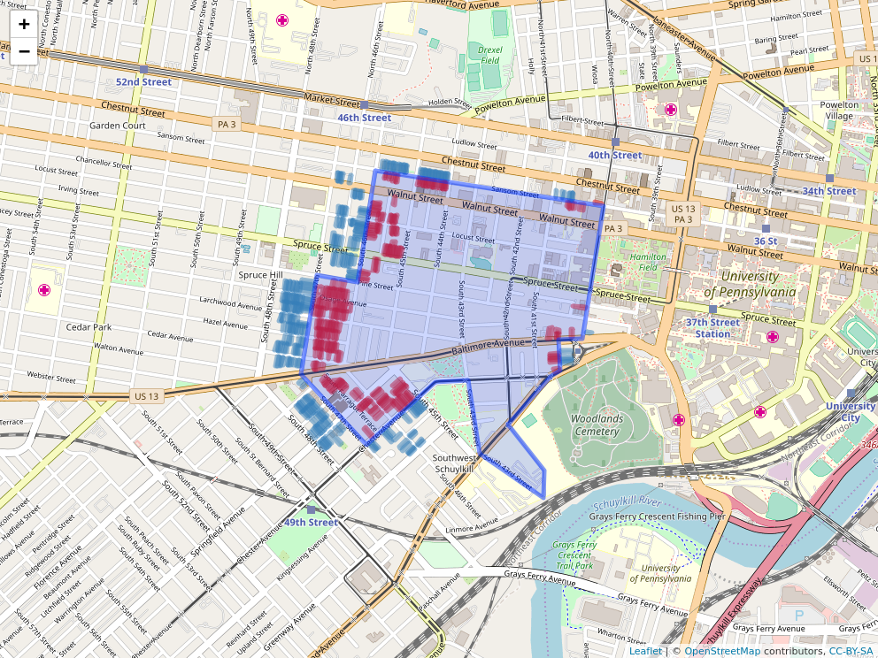